# ECE 466 Homework 3

#### 3:

[20] Determine the z-transforms of the following signals and describe the pole-zero patterns and ROC. You can use the properties of z-transform.

1. $x[n] = (n+1)u[n]$.

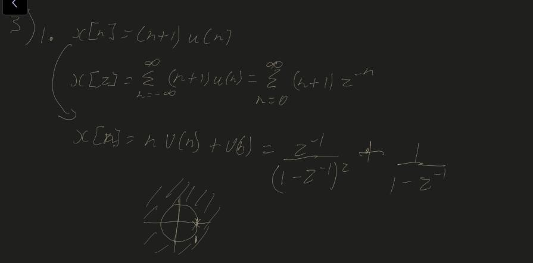

Your answers for 3.1 should be written below in this cell.

1. $x[n] = \begin{cases} (\frac{1}{3})^n, \quad & n\geq 0 \\ (\frac{1}{2})^{-n}, & n <0 \end{cases}$.

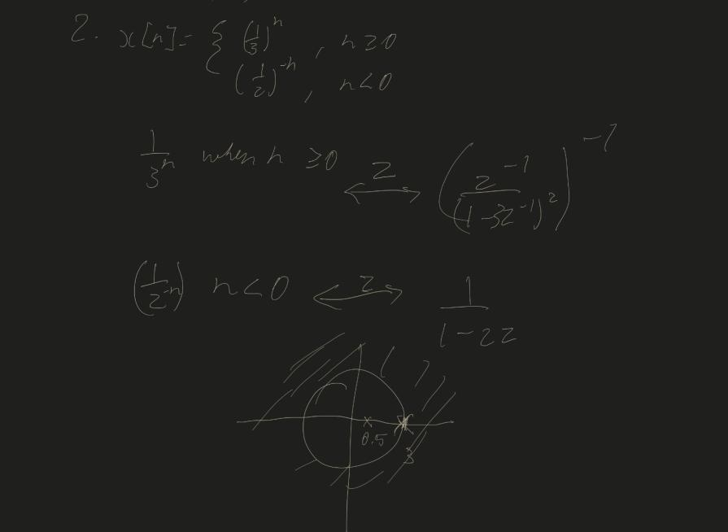

Your answers for 3.2 should be written below in this cell.

[figure not shown]

1. $x[n] = (\frac{1}{4})^n(u[n]-u[n-5])$.
1. $x[n] = (\frac{1}{2})^nu[n] \ast 2^n u[n-1]$.

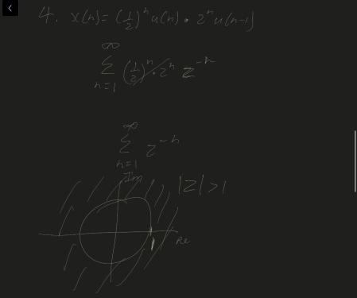

Your answers for 3.4 should be written below in this cell.

1. $x[n] = n\sin(\frac{\pi}{2}n)u[-n]$.

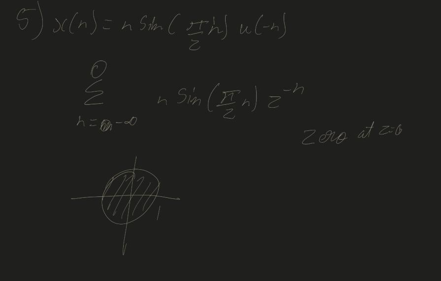

Your answers for 3.5 should be written below in this cell.